# Assessing the drivers of vessel tracking systems adoption for improved small-scale fisheries management

4/20/2021

```r
# calling raw database

raw_db <- read.csv(here("Data/master_survey_resp.csv"), stringsAsFactors = TRUE)

# data for interval regression after Gage's cleaning

interval_reg_db <- read.csv(here("Data/data_int_regression.csv"), stringsAsFactors = TRUE) %>%
# ordering variables
  select(
    survey_id,
    survey_version,
    country,
    choice,
    package,
    sos,
    info,
    own,
    community,
    years_fishing,
    age,
    boat_length_m,
    fishing_organization,
    education,
    gdp_prop,
    income_usd,
    NY.GDP.PCAP.KD,
    fishing_org_members,
    fishtech,
    boat_own,
    income_fishing,
    rank_one,
    wtp_upper,
    wtp_lower
  ) %>%
  mutate(data_owned = ifelse(own == 1, " by fisher",
                      ifelse(own == 2, " by industry",
                             ifelse(own == 3, " by goverment", "Public data"))))
# releveling factors

interval_reg_db$data_owned <- fct_relevel(interval_reg_db$data_owned, c("Public data", " by industry", " by goverment", " by fisher"))
interval_reg_db$education <- fct_relevel(interval_reg_db$education, c("no_formal", "formal", "higher"))
interval_reg_db$rank_one <- fct_relevel(interval_reg_db$rank_one, c("corruption", "pollution", "weather", "iuu"))

# data for clogit

master_survey <- read.csv(here("Data/master_survey_resp.csv"), stringsAsFactors = TRUE) %>%
  select(
    -(c(start,
        end,
        survey_type,
        interviewer,
        comment,
        text_vms_adoption,
        fishery_problem_one,
        fishery_problem_two,
        fishery_problem_three,
        fishery_solution_one,
        fishery_solution_two,
        fishery_solution_three,
        photo)))

clogit_db <- read_csv(here("Data/data_clogit.csv")) %>%
  left_join(master_survey, by = "survey_id") %>%
  select(-noalt) %>%
  mutate(own = as.factor(own)) %>%
  mutate(info = as.factor(info)) %>%
  #dummy variables column for country, indo = 1 mex = 0
  mutate(country_dum = ifelse(country == 'IND', 1, 0)) %>%
  mutate(country_dum = as.factor(country_dum),
  data_owned = ifelse(own == 1, " by fisher",
                      ifelse(own == 2, " by industry",
                             ifelse(own == 3, " by goverment", "Public data"))),
  sos = ifelse(sos == 1, "With", "Whithout"),
  info = ifelse(info == 1, "Non-anonymous", "Anonymous")
  )
# reordering levels for info and ownership in clogit dataset

clogit_db$data_owned <- fct_relevel(clogit_db$data_owned, c("Public data", " by fisher", " by industry", " by goverment"))
clogit_db$info <- fct_relevel(clogit_db$info, c("Anonymous", "Non-anonymous"))
```

## **1. Data exploration**

These are things I found in the code that need to be informed in the manuscript or suplemetary info.

1. Willingness to pay intervals
- For IND
  - wtp_1 = $2.14
  - wtp_2 = $3.56
  - wtp_3 = $5.35
  - wtp_4 = $7.12
- For MEX
  - wtp_1 = $2.07
  - wtp_2 = $3.62
  - wtp_3 = $5.17
  - wtp_4 = $7.75
2. Income error in WKB
- Huge distribution of income in IND, especially in WKB (10^7 difference) min is a single digit number, which does not make sense for Indonesia (Annual income for lowest income would be $0.0043)
3. Currency conversion
- 0.000071 USD / 1 Indonesian Rupiah
- 0.052 USD / 1 Medican Peso
4. Gapfilling
- gapfill means for each village for variable “fishing_org_members”… except for MNC.. gapfill with overall indonesia mean 61.86538 is the average fishing org size from survey in IND round up to 62

### **1.a. Summary stats**

|  |  | IND (N=107) Mean | IND (N=107) Std. Dev. | MEX (N=81) Mean | MEX (N=81) Std. Dev. | Diff. in Means | p |
| --- | --- | --- | --- | --- | --- | --- | --- |
| years_fishing |  | 22.57 | 13.27 | 26.21 | 13.30 | 3.64 | 0.06 |
| age |  | 40.95 | 10.62 | 44.05 | 13.28 | 3.10 | 0.09 |
| boat_length_m |  | 10.60 | 9.93 | 7.65 | 1.73 | -2.94 | 0.00 |
| gdp_prop |  | 0.67 | 0.69 | 1.16 | 1.42 | 0.49 | 0.00 |
| income_usd |  | 2870.83 | 2943.71 | 12072.44 | 14769.70 | 9201.61 | 0.00 |
| NY.GDP.PCAP.KD |  | 4284.69 | 0.00 | 10385.83 | 0.00 | 6101.15 |  |
| fishing_org_members |  | 67.79 | 67.10 | 38.60 | 35.72 | -29.18 | 0.00 |
| income_fishing |  | 80.23 | 34.24 | 85.49 | 23.03 | 5.26 | 0.21 |
| wtp_upper |  | 3.86 | 2.83 | 6.70 | 4.48 | 2.84 | 0.00 |
| wtp_lower |  | 1.93 | 2.58 | 3.87 | 3.04 | 1.94 | 0.00 |
|  |  | N | % | N | % |  |  |
| fishing_organization | n | 54 | 50.5 | 9 | 11.1 |  |  |
|  | y | 53 | 49.5 | 72 | 88.9 |  |  |
| education | no_formal | 5 | 4.7 | 2 | 2.5 |  |  |
|  | formal | 96 | 89.7 | 71 | 87.7 |  |  |
|  | higher | 6 | 5.6 | 8 | 9.9 |  |  |
| fishtech | n | 68 | 63.6 | 0 | 0.0 |  |  |
|  | y | 39 | 36.4 | 81 | 100.0 |  |  |
| boat_own | n | 50 | 46.7 | 18 | 22.2 |  |  |
|  | y | 57 | 53.3 | 63 | 77.8 |  |  |
| rank_one | corruption | 5 | 4.7 | 25 | 30.9 |  |  |
|  | pollution | 12 | 11.2 | 32 | 39.5 |  |  |
|  | weather | 72 | 67.3 | 2 | 2.5 |  |  |
|  | iuu | 18 | 16.8 | 22 | 27.2 |  |  |
| data_owned | Public data | 26 | 24.3 | 25 | 30.9 |  |  |
|  | by industry | 14 | 13.1 | 11 | 13.6 |  |  |
|  | by goverment | 30 | 28.0 | 19 | 23.5 |  |  |
|  | by fisher | 37 | 34.6 | 26 | 32.1 |  |  |

## **2. Conditional logit regression to analyze preferences on attributes**

- We do not need to account for country differences here because the clogit controls for subjects fixed characteristics.
- The conditional logit assumes homogeneous preferences across respondents. It accounts for demographics but assumes that preferences are constant. If we would like to allowed for heterogenous preferences we would need to apply a [Random Paramater Logit](https://cran.r-project.org/web/packages/mlogit/vignettes/c5.mxl.html).

|  | clogit | clogit_only_ind | clogit_only_mex | clogit_country_attribute_interaction | clogit_country_attribute_interaction_ii |
| --- | --- | --- | --- | --- | --- |
| sosWith | 2.455*** | 2.336*** | 3.174*** |  | 3.174*** |
|  | [1.816, 3.094] | [1.473, 3.199] | [1.905, 4.442] |  | [1.905, 4.442] |
| infoNon-anonymous | -0.132 | -0.233 | -0.418 |  | -0.418 |
|  | [-0.809, 0.546] | [-1.095, 0.630] | [-1.785, 0.949] |  | [-1.785, 0.949] |
| data_owned by fisher | 1.204*** | 1.576*** | 0.980 |  | 0.980 |
|  | [0.365, 2.043] | [0.413, 2.738] | [-0.434, 2.394] |  | [-0.434, 2.394] |
| data_owned by industry | -0.313 | -0.026 | -0.657 |  | -0.657 |
|  | [-1.463, 0.837] | [-1.579, 1.528] | [-2.456, 1.141] |  | [-2.456, 1.141] |
| data_owned by goverment | 1.227* | 2.099** | -0.253 |  | -0.253 |
|  | [-0.147, 2.601] | [0.119, 4.079] | [-2.487, 1.981] |  | [-2.487, 1.981] |
| interaction(sos, country)With.IND |  |  |  | 2.336*** |  |
|  |  |  |  | [1.473, 3.199] |  |
| interaction(sos, country)Whithout.MEX |  |  |  | -3.174*** |  |
|  |  |  |  | [-4.442, -1.905] |  |
| interaction(sos, country)With.MEX |  |  |  | NA |  |
|  |  |  |  | [, ] |  |
| interaction(info, country)Non-anonymous.IND |  |  |  | -0.233 |  |
|  |  |  |  | [-1.095, 0.630] |  |
| interaction(info, country)Anonymous.MEX |  |  |  | 0.418 |  |
|  |  |  |  | [-0.949, 1.785] |  |
| interaction(info, country)Non-anonymous.MEX |  |  |  | NA |  |
|  |  |  |  | [, ] |  |
| interaction(data_owned, country) by fisher.IND |  |  |  | 1.576*** |  |
|  |  |  |  | [0.413, 2.738] |  |
| interaction(data_owned, country) by industry.IND |  |  |  | -0.026 |  |
|  |  |  |  | [-1.579, 1.528] |  |
| interaction(data_owned, country) by goverment.IND |  |  |  | 2.099** |  |
|  |  |  |  | [0.119, 4.079] |  |
| interaction(data_owned, country)Public data.MEX |  |  |  | 0.253 |  |
|  |  |  |  | [-1.981, 2.487] |  |
| interaction(data_owned, country) by fisher.MEX |  |  |  | 1.233 |  |
|  |  |  |  | [-1.050, 3.516] |  |
| interaction(data_owned, country) by industry.MEX |  |  |  | -0.405 |  |
|  |  |  |  | [-2.022, 1.213] |  |
| interaction(data_owned, country) by goverment.MEX |  |  |  | NA |  |
|  |  |  |  | [, ] |  |
| indo |  |  |  |  | NA |
|  |  |  |  |  | [, ] |
| sosWith × indo |  |  |  |  | -0.838 |
|  |  |  |  |  | [-2.372, 0.696] |
| infoNon-anonymous × indo |  |  |  |  | 0.185 |
|  |  |  |  |  | [-1.431, 1.802] |
| data_owned by fisher × indo |  |  |  |  | 0.596 |
|  |  |  |  |  | [-1.235, 2.426] |
| data_owned by industry × indo |  |  |  |  | 0.632 |
|  |  |  |  |  | [-1.745, 3.008] |
| data_owned by goverment × indo |  |  |  |  | 2.352 |
|  |  |  |  |  | [-0.633, 5.337] |
| Num.Obs. | 422 | 248 | 174 | 422 | 422 |
| R2 | 0.290 | 0.275 | 0.339 | 0.302 | 0.302 |
| AIC | 158.2 | 102.2 | 58.4 | 160.6 | 160.6 |
| BIC | 175.0 | 116.3 | 70.8 | 194.1 | 194.1 |
| Log.Lik. | -74.111 | -46.091 | -24.220 | -70.311 | -70.311 |
| concordance | 0.877 | 0.871 | 0.885 | 0.877 | 0.877 |
| n | 422.000 | 248.000 | 174.000 | 422.000 | 422.000 |
| nevent | 211.000 | 124.000 | 87.000 | 211.000 | 211.000 |
| p.value.log | 0.000 | 0.000 | 0.000 | 0.000 | 0.000 |
| p.value.robust |  |  |  |  |  |
| p.value.sc | 0.000 | 0.000 | 0.000 | 0.000 | 0.000 |
| p.value.wald | 0.000 | 0.000 | 0.000 | 0.000 | 0.000 |
| r.squared.max | 0.500 | 0.500 | 0.500 | 0.500 | 0.500 |
| statistic.log | 144.287 | 79.719 | 72.168 | 151.887 | 151.887 |
| statistic.robust |  |  |  |  |  |
| statistic.sc | 117.835 | 64.521 | 56.856 | 121.376 | 121.376 |
| statistic.wald | 73.680 | 40.390 | 28.840 | 69.230 | 69.230 |
| std.error.concordance | 0.032 | 0.043 | 0.048 | 0.032 | 0.032 |

## **3. Analyzing willingness to pay**

### 3.a Interval regression models

|  | int_tech | int | int_1 | int_2 | int_3 | int_4 | int_5 | int_6 | int_7 | int_8 | int_9 | int_10 | int_11 | int_12 | int_13 | int_15 | int_16 |
| --- | --- | --- | --- | --- | --- | --- | --- | --- | --- | --- | --- | --- | --- | --- | --- | --- | --- |
| (Intercept) | 2.677*** | 1.054 | 1.204 | 1.357 | 0.118 | 0.003 | 0.061 | 0.049 | 0.052 | 1.354* | 1.288 | 0.644 | 1.644* | 3.493*** | 2.929*** | 1.468 | 1.528 |
|  | (0.710) | (1.289) | (1.336) | (1.301) | (1.272) | (1.259) | (1.299) | (1.298) | (1.257) | (0.733) | (0.804) | (0.795) | (0.911) | (0.914) | (0.985) | (1.255) | (1.262) |
| sos | 1.605*** | 1.373** | 1.485** | 1.510*** | 1.344** | 1.289** | 1.337** | 1.297** | 1.335** | 1.399** | 1.408** | 1.451*** | 1.413** | 1.481*** | 1.467*** | 1.268** | 1.298** |
|  | (0.580) | (0.586) | (0.587) | (0.582) | (0.556) | (0.560) | (0.560) | (0.563) | (0.555) | (0.556) | (0.558) | (0.551) | (0.557) | (0.533) | (0.526) | (0.527) | (0.532) |
| info | -0.435 | -0.441 | -0.459 | -0.443 | -0.389 | -0.393 | -0.401 | -0.396 | -0.400 | -0.359 | -0.358 | -0.361 | -0.339 | -0.358 | -0.352 | -0.414 | -0.419 |
|  | (0.448) | (0.442) | (0.445) | (0.445) | (0.424) | (0.423) | (0.424) | (0.424) | (0.423) | (0.425) | (0.425) | (0.421) | (0.427) | (0.407) | (0.406) | (0.402) | (0.402) |
| data_owned by industry | 0.371 | 0.573 | 0.481 | 0.492 | 0.827 | 0.852 | 0.824 | 0.855 | 0.823 | 0.750 | 0.766 | 0.735 | 0.779 | 0.886 | 0.874 | 1.089 | 1.075 |
|  | (0.752) | (0.748) | (0.749) | (0.748) | (0.719) | (0.719) | (0.719) | (0.720) | (0.719) | (0.720) | (0.725) | (0.712) | (0.721) | (0.691) | (0.688) | (0.686) | (0.687) |
| data_owned by goverment | -0.568 | -0.465 | -0.523 | -0.480 | -0.505 | -0.505 | -0.525 | -0.497 | -0.527 | -0.561 | -0.546 | -0.434 | -0.550 | -0.479 | -0.410 | -0.375 | -0.385 |
|  | (0.611) | (0.604) | (0.607) | (0.609) | (0.580) | (0.577) | (0.578) | (0.580) | (0.577) | (0.581) | (0.585) | (0.577) | (0.581) | (0.557) | (0.557) | (0.549) | (0.550) |
| data_owned by fisher | 0.437 | 0.452 | 0.488 | 0.503 | 0.613 | 0.587 | 0.607 | 0.589 | 0.607 | 0.546 | 0.568 | 0.751 | 0.564 | 0.789 | 0.859 | 0.834 | 0.855 |
|  | (0.599) | (0.590) | (0.592) | (0.592) | (0.565) | (0.565) | (0.565) | (0.565) | (0.565) | (0.570) | (0.580) | (0.571) | (0.570) | (0.553) | (0.554) | (0.542) | (0.544) |
| Log(scale) | 1.093*** | 1.074*** | 1.079*** | 1.079*** | 1.028*** | 1.027*** | 1.028*** | 1.027*** | 1.028*** | 1.037*** | 1.037*** | 1.025*** | 1.036*** | 0.990*** | 0.987*** | 0.973*** | 0.973*** |
|  | (0.057) | (0.057) | (0.057) | (0.057) | (0.057) | (0.057) | (0.057) | (0.057) | (0.057) | (0.057) | (0.057) | (0.057) | (0.057) | (0.057) | (0.057) | (0.057) | (0.057) |
| educationformal |  | 1.444 | 1.427 | 1.430 | 1.434 | 1.439 | 1.431 | 1.437 | 1.431 |  |  |  |  |  |  | 2.358** | 2.368** |
|  |  | (1.186) | (1.192) | (1.191) | (1.135) | (1.135) | (1.135) | (1.135) | (1.135) |  |  |  |  |  |  | (1.099) | (1.098) |
| educationhigher |  | 2.835** | 2.845** | 2.850** | 2.393* | 2.395* | 2.380* | 2.383* | 2.382* |  |  |  |  |  |  | 3.265** | 3.267** |
|  |  | (1.410) | (1.419) | (1.416) | (1.353) | (1.352) | (1.356) | (1.355) | (1.353) |  |  |  |  |  |  | (1.304) | (1.303) |
| gdp_prop |  | 0.291 |  |  |  | 0.122 |  | 0.127 |  | 0.116 | 0.108 | 0.076 | 0.126 | -0.079 |  |  | -0.083 |
|  |  | (0.205) |  |  |  | (0.200) |  | (0.204) |  | (0.202) | (0.206) | (0.200) | (0.203) | (0.201) |  |  | (0.198) |
| years_fishing |  |  | 0.002 |  |  |  | 0.000 | -0.002 |  |  |  |  |  |  |  |  |  |
|  |  |  | (0.017) |  |  |  | (0.016) | (0.016) |  |  |  |  |  |  |  |  |  |
| boat_length_m |  |  |  | -0.016 | -0.009 |  |  |  |  |  |  |  |  |  |  |  |  |
|  |  |  |  | (0.029) | (0.027) |  |  |  |  |  |  |  |  |  |  |  |  |
| fishtech |  |  |  |  | 1.937*** | 1.890*** | 1.946*** | 1.891*** | 1.945*** | 1.966*** | 1.957*** | 1.891*** | 1.940*** | 1.371*** | 1.359*** | 1.204*** | 1.230*** |
|  |  |  |  |  | (0.444) | (0.452) | (0.444) | (0.452) | (0.444) | (0.453) | (0.455) | (0.449) | (0.455) | (0.461) | (0.455) | (0.454) | (0.458) |
| boat_own |  |  |  |  |  |  |  |  |  |  | 0.092 |  |  |  |  |  |  |
|  |  |  |  |  |  |  |  |  |  |  | (0.463) |  |  |  |  |  |  |
| fishing_organizationy |  |  |  |  |  |  |  |  |  |  |  | 0.983** |  |  | 0.569 |  |  |
|  |  |  |  |  |  |  |  |  |  |  |  | (0.453) |  |  | (0.468) |  |  |
| income_fishing |  |  |  |  |  |  |  |  |  |  |  |  | -0.004 |  |  |  |  |
|  |  |  |  |  |  |  |  |  |  |  |  |  | (0.007) |  |  |  |  |
| rank_onepollution |  |  |  |  |  |  |  |  |  |  |  |  |  | -1.842*** | -1.801*** | -1.918*** | -1.975*** |
|  |  |  |  |  |  |  |  |  |  |  |  |  |  | (0.689) | (0.674) | (0.671) | (0.684) |
| rank_oneweather |  |  |  |  |  |  |  |  |  |  |  |  |  | -2.715*** | -2.482*** | -2.935*** | -2.989*** |
|  |  |  |  |  |  |  |  |  |  |  |  |  |  | (0.665) | (0.668) | (0.655) | (0.668) |
| rank_oneiuu |  |  |  |  |  |  |  |  |  |  |  |  |  | -1.261* | -1.307* | -1.469** | -1.477** |
|  |  |  |  |  |  |  |  |  |  |  |  |  |  | (0.692) | (0.691) | (0.688) | (0.688) |
| Num.Obs. | 188 | 188 | 188 | 188 | 188 | 188 | 188 | 188 | 188 | 188 | 188 | 188 | 188 | 188 | 188 | 188 | 188 |
| AIC | 705.4 | 704.9 | 706.9 | 706.6 | 690.4 | 690.1 | 690.5 | 692.1 | 688.5 | 689.3 | 691.3 | 686.6 | 691.0 | 678.0 | 676.7 | 673.9 | 675.8 |
| BIC | 728.0 | 737.3 | 739.3 | 739.0 | 726.0 | 725.7 | 726.1 | 730.9 | 720.9 | 718.4 | 723.6 | 719.0 | 723.4 | 716.8 | 715.5 | 716.0 | 721.1 |
| Log.Lik. | -345.686 | -342.464 | -343.457 | -343.318 | -334.195 | -334.066 | -334.251 | -334.056 | -334.251 | -335.655 | -335.635 | -333.320 | -335.512 | -327.002 | -326.343 | -323.968 | -323.880 |
| iter | 3.000 | 3.000 | 3.000 | 3.000 | 3.000 | 3.000 | 3.000 | 3.000 | 3.000 | 3.000 | 3.000 | 3.000 | 3.000 | 4.000 | 4.000 | 4.000 | 4.000 |

### 3.b. Interval regression models with random effects by country

|  | model_1 | model_2 | model_3 | model_4 | model_5 | model_6 | model_7 | model_8 | model_9 | model_10 | model_11 | model_12 | model_13 | model_14 | model_15 | model_16 | model_17 |
| --- | --- | --- | --- | --- | --- | --- | --- | --- | --- | --- | --- | --- | --- | --- | --- | --- | --- |
| Privacy | -0.52 | -0.54 | -0.56 | -0.56 | -0.47 | -0.47 | -0.48 | -0.48 | -0.47 | -0.44 | -0.44 | -0.41 | -0.41 | -0.36 | -0.35 | -0.41 | -0.42 |
|  | (0.43) | (0.42) | (0.42) | (0.42) | (0.42) | (0.42) | (0.42) | (0.42) | (0.42) | (0.42) | (0.42) | (0.42) | (0.42) | (0.41) | (0.41) | (0.40) | (0.40) |
| SOS | 1.44*** | 1.31** | 1.39** | 1.34** | 1.31** | 1.28** | 1.34** | 1.31** | 1.31** | 1.39** | 1.38** | 1.43*** | 1.41** | 1.48*** | 1.47*** | 1.27** | 1.30** |
|  | (0.55) | (0.56) | (0.56) | (0.55) | (0.55) | (0.55) | (0.55) | (0.56) | (0.55) | (0.55) | (0.55) | (0.55) | (0.55) | (0.53) | (0.53) | (0.53) | (0.53) |
| Data_industry | 0.47 | 0.60 | 0.57 | 0.56 | 0.74 | 0.76 | 0.74 | 0.77 | 0.74 | 0.67 | 0.65 | 0.68 | 0.71 | 0.89 | 0.87 | 1.09 | 1.07 |
|  | (0.71) | (0.71) | (0.71) | (0.71) | (0.71) | (0.71) | (0.71) | (0.71) | (0.71) | (0.71) | (0.72) | (0.71) | (0.71) | (0.69) | (0.69) | (0.69) | (0.69) |
| Data_goverment | -0.38 | -0.32 | -0.31 | -0.35 | -0.42 | -0.41 | -0.40 | -0.38 | -0.42 | -0.46 | -0.47 | -0.40 | -0.43 | -0.48 | -0.41 | -0.37 | -0.38 |
|  | (0.58) | (0.58) | (0.58) | (0.58) | (0.57) | (0.57) | (0.57) | (0.58) | (0.57) | (0.58) | (0.58) | (0.57) | (0.58) | (0.56) | (0.56) | (0.55) | (0.55) |
| Data_fisher | 0.54 | 0.57 | 0.59 | 0.58 | 0.61 | 0.60 | 0.62 | 0.61 | 0.61 | 0.56 | 0.54 | 0.71 | 0.59 | 0.79 | 0.86 | 0.83 | 0.86 |
|  | (0.57) | (0.56) | (0.56) | (0.56) | (0.56) | (0.56) | (0.56) | (0.56) | (0.56) | (0.56) | (0.57) | (0.57) | (0.56) | (0.55) | (0.55) | (0.54) | (0.54) |
| Formal_education |  | 1.28 | 1.26 | 1.26 | 1.34 | 1.34 | 1.33 | 1.34 | 1.34 |  |  |  |  |  |  | 2.36** | 2.37** |
|  |  | (1.13) | (1.13) | (1.13) | (1.12) | (1.12) | (1.12) | (1.12) | (1.12) |  |  |  |  |  |  | (1.10) | (1.10) |
| Higher_education |  | 2.40* | 2.34* | 2.37* | 2.30* | 2.31* | 2.27* | 2.27* | 2.30* |  |  |  |  |  |  | 3.27** | 3.27** |
|  |  | (1.35) | (1.35) | (1.35) | (1.34) | (1.34) | (1.34) | (1.34) | (1.34) |  |  |  |  |  |  | (1.30) | (1.30) |
| GDP |  | 0.10 |  |  |  | 0.08 |  | 0.09 |  | 0.07 | 0.08 | 0.06 | 0.09 | -0.08 |  |  | -0.08 |
|  |  | (0.20) |  |  |  | (0.20) |  | (0.20) |  | (0.20) | (0.20) | (0.20) | (0.20) | (0.20) |  |  | (0.20) |
| Years_fishing |  |  | -0.01 |  |  |  | -0.01 | -0.01 |  |  |  |  |  |  |  |  |  |
|  |  |  | (0.02) |  |  |  | (0.02) | (0.02) |  |  |  |  |  |  |  |  |  |
| Boat_length |  |  |  | 0.01 | 0.00 |  |  |  |  |  |  |  |  |  |  |  |  |
|  |  |  |  | (0.03) | (0.03) |  |  |  |  |  |  |  |  |  |  |  |  |
| Exposure_technology |  |  |  |  | 1.20** | 1.19** | 1.19** | 1.16** | 1.21** | 1.25** | 1.25** | 1.43** | 1.15** | 1.37*** | 1.36*** | 1.20*** | 1.23*** |
|  |  |  |  |  | (0.56) | (0.56) | (0.56) | (0.56) | (0.56) | (0.56) | (0.56) | (0.57) | (0.57) | (0.46) | (0.46) | (0.46) | (0.46) |
| Boat_owner |  |  |  |  |  |  |  |  |  |  | -0.09 |  |  |  |  |  |  |
|  |  |  |  |  |  |  |  |  |  |  | (0.47) |  |  |  |  |  |  |
| Organized |  |  |  |  |  |  |  |  |  |  |  | 0.72 |  |  | 0.57 |  |  |
|  |  |  |  |  |  |  |  |  |  |  |  | (0.49) |  |  | (0.47) |  |  |
| Income_fishing |  |  |  |  |  |  |  |  |  |  |  |  | -0.01 |  |  |  |  |
|  |  |  |  |  |  |  |  |  |  |  |  |  | (0.01) |  |  |  |  |
| Pollution |  |  |  |  |  |  |  |  |  |  |  |  |  | -1.84*** | -1.80*** | -1.92*** | -1.98*** |
|  |  |  |  |  |  |  |  |  |  |  |  |  |  | (0.69) | (0.67) | (0.67) | (0.68) |
| Weather |  |  |  |  |  |  |  |  |  |  |  |  |  | -2.71*** | -2.48*** | -2.93*** | -2.99*** |
|  |  |  |  |  |  |  |  |  |  |  |  |  |  | (0.67) | (0.67) | (0.66) | (0.67) |
| IUU |  |  |  |  |  |  |  |  |  |  |  |  |  | -1.26* | -1.31* | -1.47** | -1.48** |
|  |  |  |  |  |  |  |  |  |  |  |  |  |  | (0.69) | (0.69) | (0.69) | (0.69) |
| Constant | 3.32*** | 1.94 | 2.24 | 2.00 | 0.86 | 0.82 | 1.01 | 0.98 | 0.87 | 2.09** | 2.17** | 1.30 | 2.65** | 3.49*** | 2.93*** | 1.47 | 1.53 |
|  | (1.19) | (1.59) | (1.62) | (1.58) | (1.44) | (1.44) | (1.49) | (1.49) | (1.44) | (1.00) | (1.09) | (1.10) | (1.19) | (0.92) | (0.99) | (1.26) | (1.26) |
| Num.Obs. | 188 | 188 | 188 | 188 | 188 | 188 | 188 | 188 | 188 | 188 | 188 | 188 | 188 | 188 | 188 | 188 | 188 |
| AIC | 684.2 | 687.2 | 687.2 | 687.3 | 686.3 | 686.3 | 686.2 | 688.0 | 684.4 | 684.9 | 686.9 | 685.1 | 686.2 | 678.0 | 676.7 | 673.9 | 675.7 |
| BIC | 707.9 | 721.5 | 721.5 | 721.6 | 723.9 | 723.8 | 723.8 | 728.8 | 718.7 | 715.5 | 720.8 | 718.6 | 720.2 | 716.8 | 715.5 | 716.0 | 721.0 |
| RMSE | 2.89 | 2.86 | 2.86 | 2.86 | 2.83 | 2.83 | 2.83 | 2.83 | 2.83 | 2.86 | 2.86 | 2.85 | 2.85 | 2.79 | 2.78 | 2.75 | 2.75 |

## **4. Simulations**

Model key:

info == 0 ~ “Anon”, info == 1 ~ “Non-Anon”

own == 1 ~ “Fishers”, own == 2 ~ “Industry”, own == 3 ~ “Government”, own == 4 ~ “Public Access”

sos == 0 ~ “No”, sos == 1 ~ “Yes”

We want to simulate 4 scenarios:

1. Best package in the “worst community”
2. Best package in the “best community”
3. Worst package in the “worst community”
4. Worst package in the “best community”

Based off Table 4 in the GP report the best package is one with SOS functionality and generating anonymous-data owned by the government while the worst package presents no SOS functionality and non-anonymous data owned by the industry. Based off the interval regression model a village in which all fishers have been previously exposed to technology, have higher education and perceive corruption as the main problem would present the highest WTP. The lowest WTP would be observed in a village in which none fisher has been exposed to previous technology, have only non-formal education and perceive weather as the main threat to fishing.

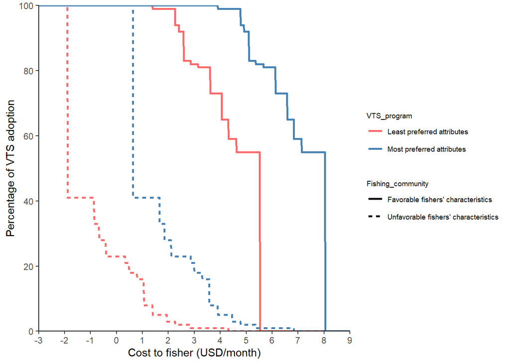